# Analyzing the Presidential Election 2016 funding data by Andrii Zakharov

This is the analysis of contributions to presidential candidates 2016 in the state of California. The dataset contains 1,125,659 observations of 18 variables.

```
## 'data.frame':    1125659 obs. of  18 variables:
##  $ cmte_id          : chr  "C00575795" "C00575795" "C00575795" "C00577130" ...
##  $ cand_id          : chr  "P00003392" "P00003392" "P00003392" "P60007168" ...
##  $ cand_nm          : chr  "Clinton, Hillary Rodham" "Clinton, Hillary Rodham" "Clinton, Hillary Rodham" "Sanders, Bernard" ...
##  $ contbr_nm        : chr  "AULL, ANNE" "CARROLL, MARYJEAN" "GANDARA, DESIREE" "LEE, ALAN" ...
##  $ contbr_city      : chr  "LARKSPUR" "CAMBRIA" "FONTANA" "CAMARILLO" ...
##  $ contbr_st        : chr  "CA" "CA" "CA" "CA" ...
##  $ contbr_zip       : chr  "949391913" "934284638" "923371507" "930111214" ...
##  $ contbr_employer  : chr  "N/A" "N/A" "N/A" "AT&T GOVERNMENT SOLUTIONS" ...
##  $ contbr_occupation: chr  "RETIRED" "RETIRED" "RETIRED" "SOFTWARE ENGINEER" ...
##  $ contb_receipt_amt: chr  "50" "200" "5" "40" ...
##  $ contb_receipt_dt : chr  "26-APR-16" "20-APR-16" "02-APR-16" "04-MAR-16" ...
##  $ receipt_desc     : chr  "" "" "" "" ...
##  $ memo_cd          : chr  "X" "X" "X" "" ...
##  $ memo_text        : chr  "* HILLARY VICTORY FUND" "* HILLARY VICTORY FUND" "* HILLARY VICTORY FUND" "* EARMARKED CONTRIBUTION: SEE BELOW" ...
##  $ form_tp          : chr  "SA18" "SA18" "SA18" "SA17A" ...
##  $ file_num         : chr  "1091718" "1091718" "1091718" "1077404" ...
##  $ tran_id          : chr  "C4768722" "C4747242" "C4666603" "VPF7BKWA097" ...
##  $ election_tp      : chr  "P2016" "P2016" "P2016" "P2016" ...
```

Most of the variables are categorical, with only one numeric, contbr_receipt_amt (contribution receipt amount), and one date, contbr_receipt_dt. I will convert these two variables accordingly. Furthermore, I will create two additional varibles, candidate gender and contributor gender. The latter I will infer from the contributors’ first names.

All in all, I will explore the following variables in this analysis: cand_nm, contbr_nm, contbr_city, contbr_occupation, contb_receipt_amt, and contb_receipt_dt.

# Univariate Plots Section

First, let’s look at the distribution of contribution amounts.

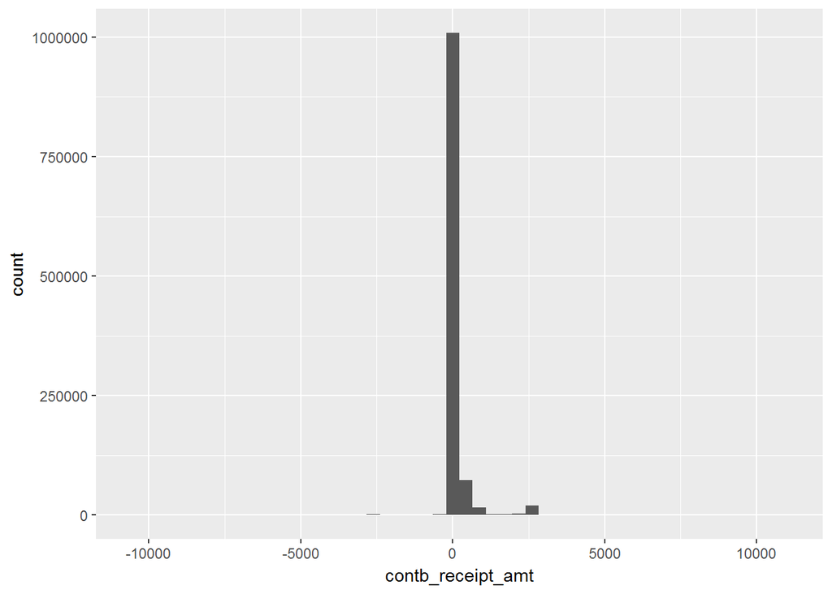

Looks like we have negative and zero contribution amounts… Let’s see how many there are.

```
##
##   FALSE    TRUE
## 1113509   12150
```

```
##
##      FALSE       TRUE
## 0.98920632 0.01079368
```

Ok, this is not so bad. Only 1% of zero or negative contribution amounts. These probably come from people changing their minds and requesting refunds. Although potentially interesting, I will exclude these observations from my analysis.

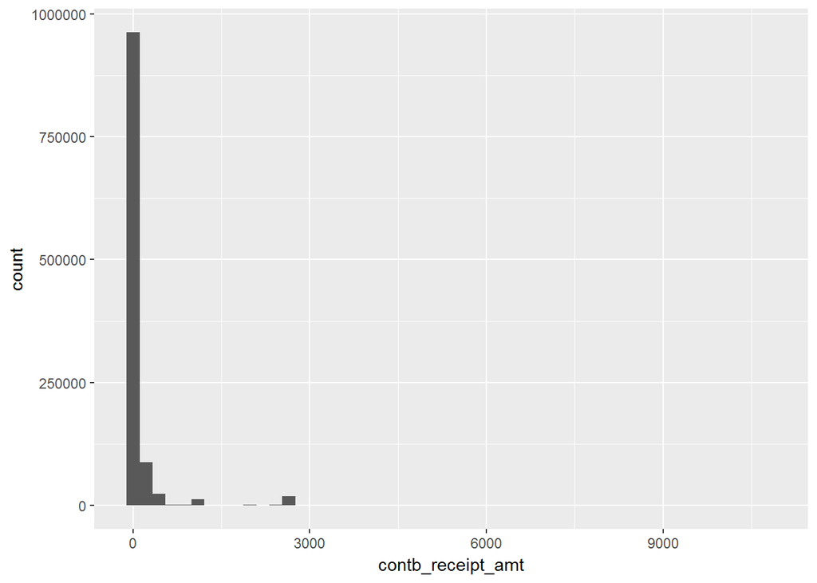

The distribution has a fat right tail, I’ll log-transform it to get a clearer picture.

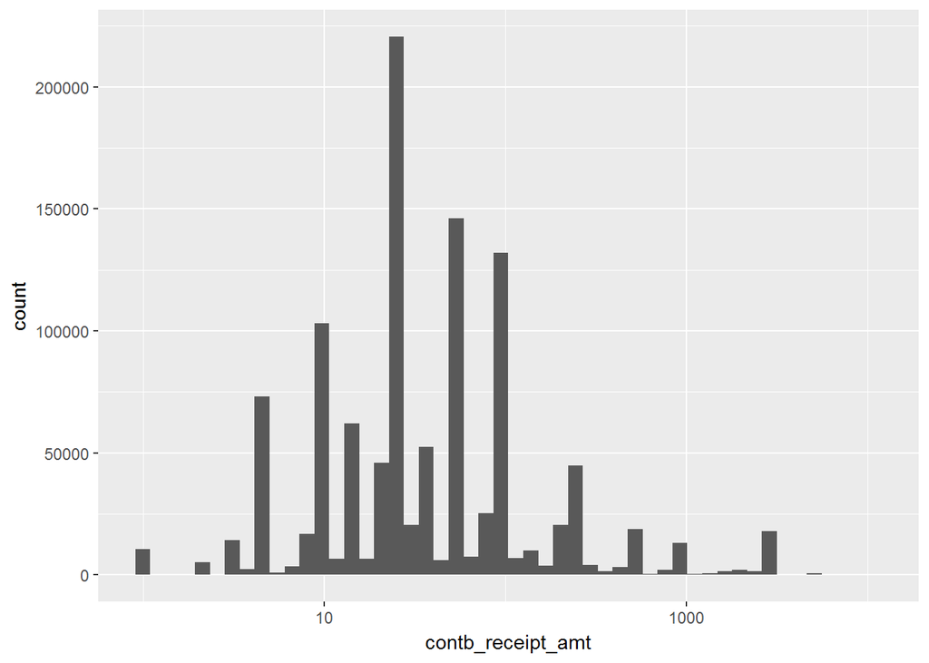

Looks like most spikes are around 10, 25 and 50 dollars.

Let’s now look at donations to different candidates.

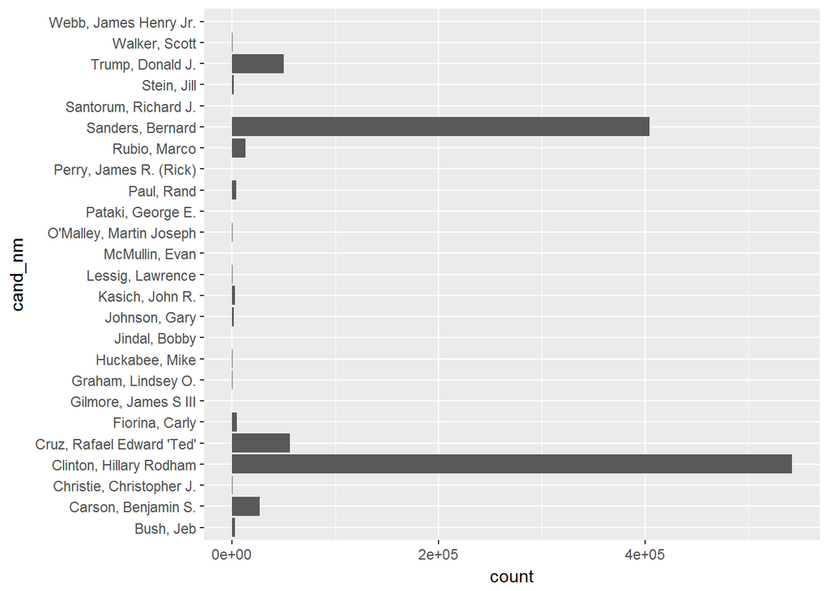

And donations from unique donors.

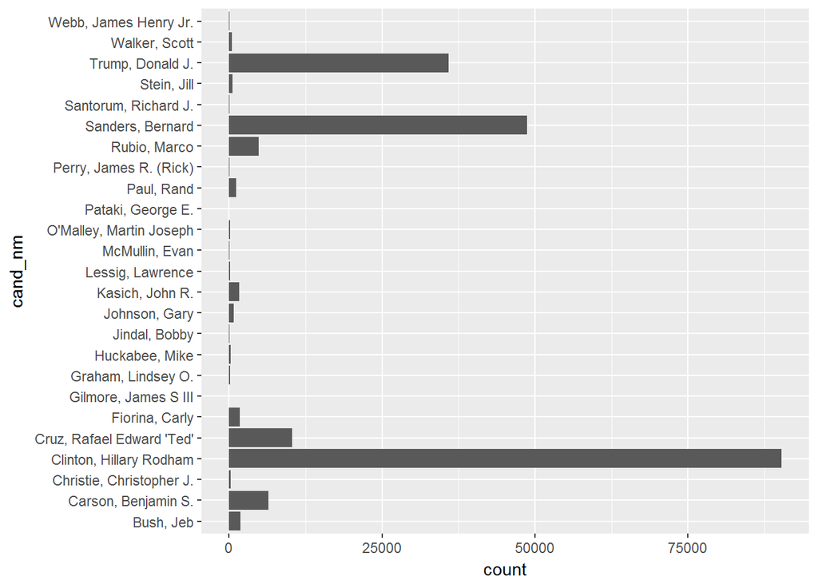

We see that Bernie and Hillary apparently had way more people donating to them more than once, compared to e.g. Trump.

How does the distribution of donation frequency by individual look like?

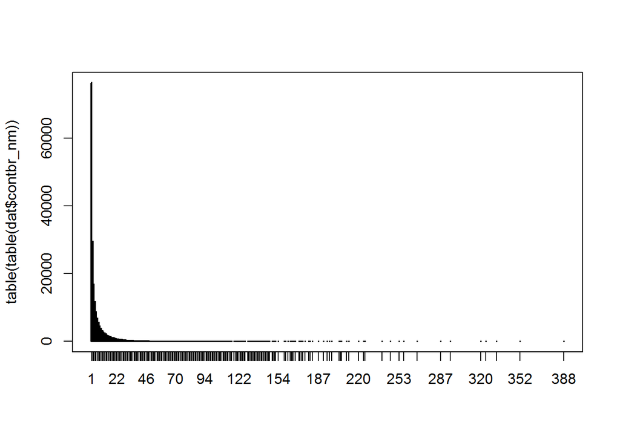

So there were people who contributed hundreds of times… Albeit only a few.

Let’s now look at cities.

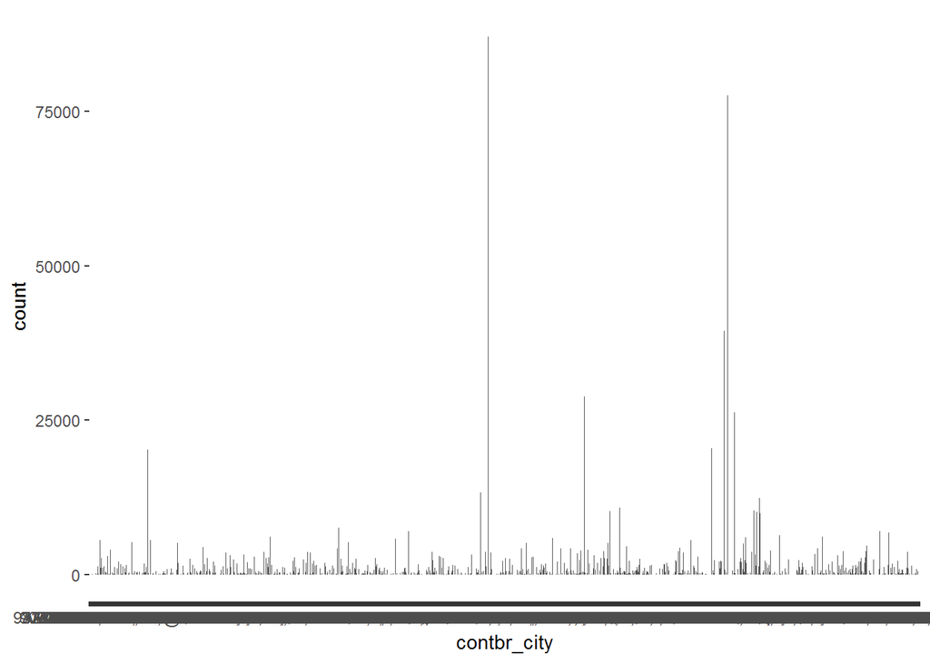

Spikes indicate bigger cities. What do the top-10 in terms of contribution numbers look like?

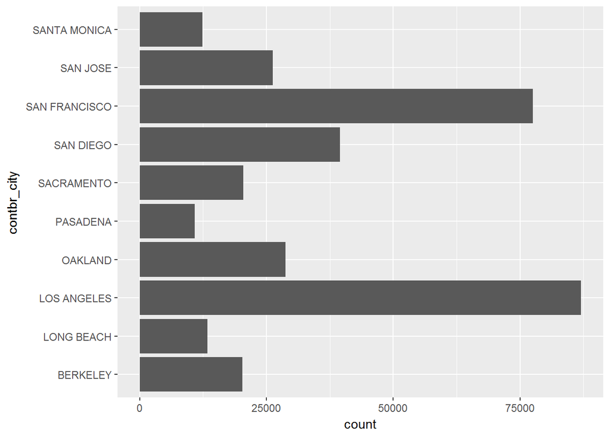

No surprises here. What about top-10 contributing occupations?

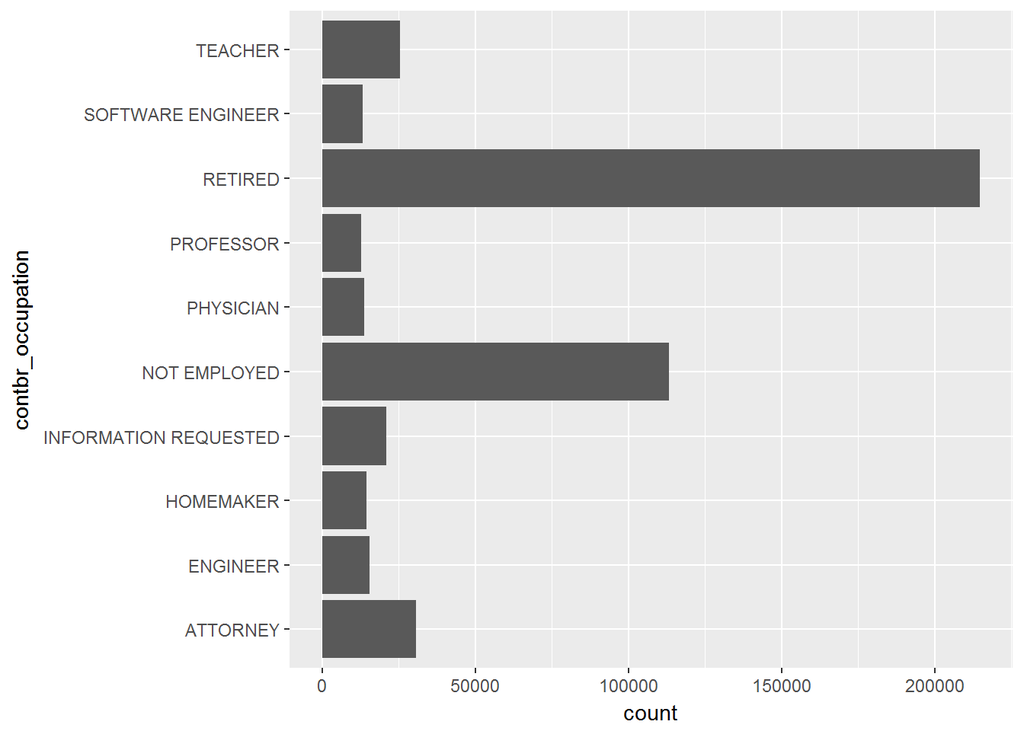

Now this is much more interesting. The most often contributing are the retired and the unemployed! How many of them do we have in the data?

```
## [1] 0.2944333
```

Together 29.44%. Quite a large chunk. I will definitely look at this in further detail.

Lastly, let’s look at the distribution of contributions by date, and the gender proportion of the contributors.

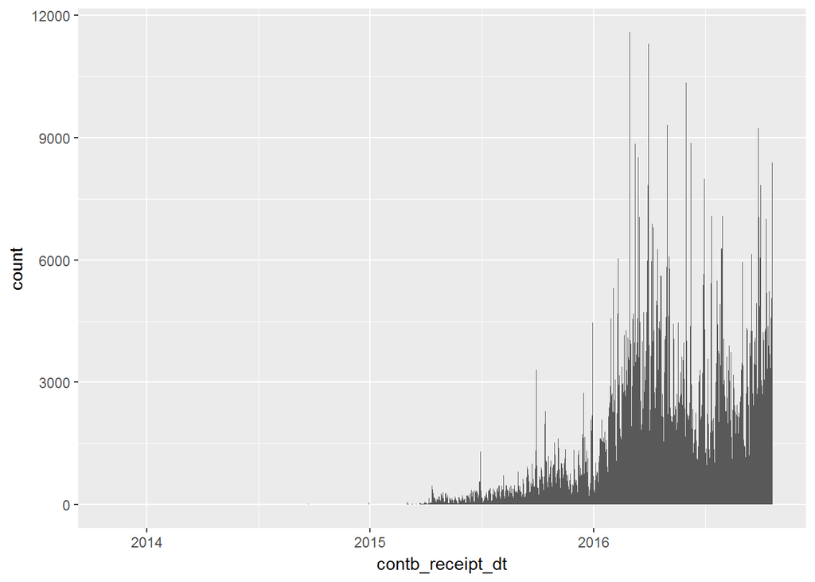

```
##
##       f       m neither
##  531748  460743  121018
```

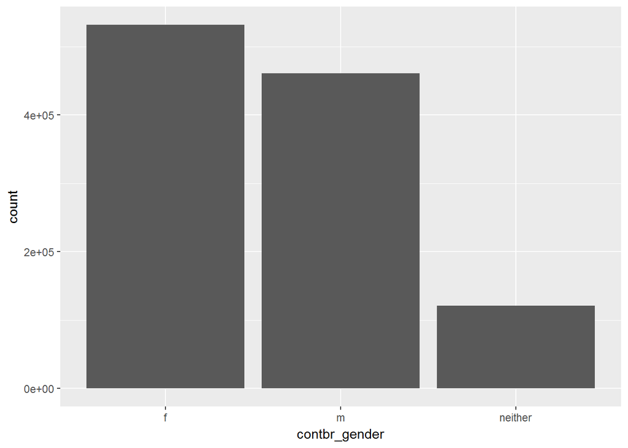

As expected, the number of donations generally increases as time passes. It could be interesting to look at the spikes, which were probably around some important dates in the campaign, like TV-debates and such.

Concerning gender, it appears that women made somewhat more contributions than men. The remaining ~10% genders I couldn’t identify.

# Univariate Analysis

### What is the structure of your dataset?

The dataset gives information about individual contributions from the state of California to presidential candidates in the 2016 election in the USA. It contains around 1.125 million transactions. The only metric variable in the dataset is the contribution amount, all others are categorical.

### What is/are the main feature(s) of interest in your dataset?

The main features of interest are the number of contributions and contribution amounts for different candidates. I’d like to see if city of residence, occupation or gender could serve as predictors for determining which candidate the donation would go to.

### What other features in the dataset do you think will help support your investigation into your feature(s) of interest?

Contributor city of residence, occupation, gender, as well as candidate gender should prove useful. Also, contribution date could be of interest.

### Did you create any new variables from existing variables in the dataset?

I added candidate gender to the dataset. That was easy as only three candidates were female.

I also tried to infer contributor gender based on their first name. This proved more difficult, but I managed to assign gender (m/f) to >89% of contributors by comparing them to the list of the most frequently used male and female first names (from https://deron.meranda.us/data/). The rest could not be identified, mostly due to exotic first names. This is undoubtedly a very crude method, appropriate to identifying trends in the data at best. I still wanted to try and see what comes out of it.

### Of the features you investigated, were there any unusual distributions? Did you perform any operations on the data to tidy, adjust, or change the form of the data? If so, why did you do this?

Some contribution amounts were negative (around 1%), which I attributed to people changing their minds about the recipient of their donation and requesting a refund. Some of those donations most probably went to different recipients, and it would be interesting to see how people changed their preferences over time. However, I felt such investigation would be beyond the scope of this project, and subsequently removed the records with negative contributions from the dataset.

# Bivariate Plots Section

We’ve seen that the retired and the unemployed donated most often. Let’s see how the donation sums for the top-10 contributing professions look like.

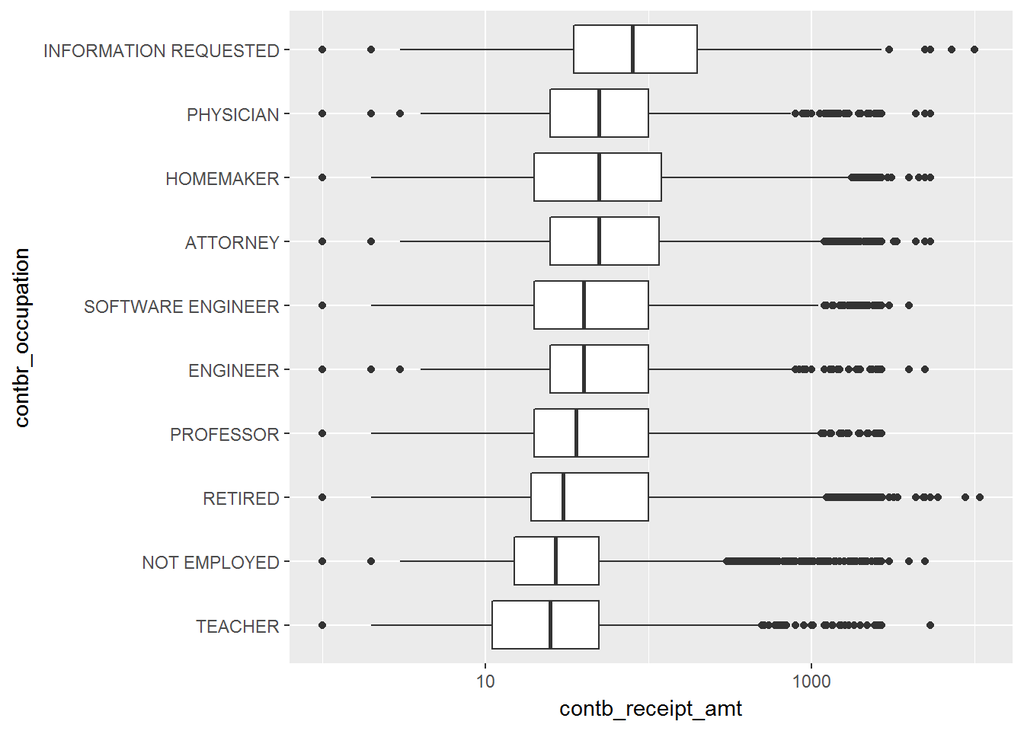

Interestingly, the highest median donation came from people who didn’t put in their occupation (the “information requested” group). The retired & unemployed didn’t donate half as much on average.

Note, however, that this doesn’t account for the fact that some people did multiple contributions. Will summarizing all contributions for each individual produce a different picture?

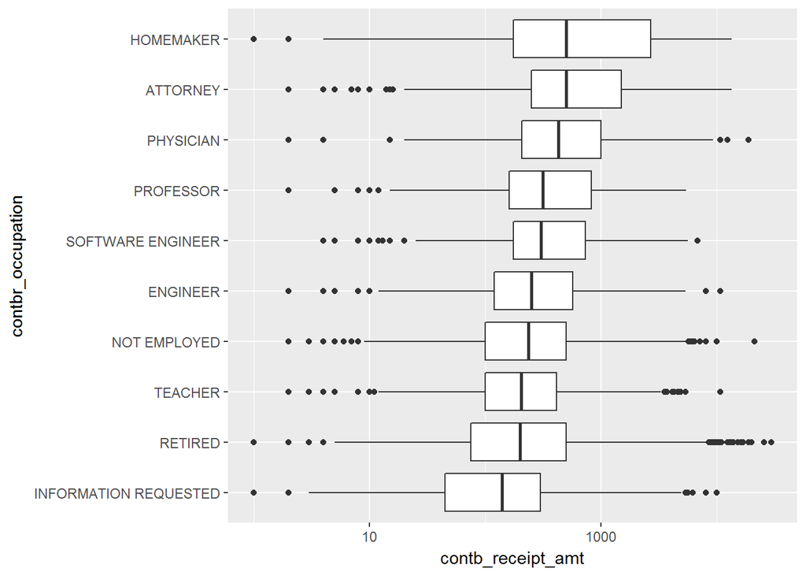

Yes, it does! Note how the “information requested” category landed at the very bottom now, with “homemaker” taking the lead. One conclusion that can be made here is that homemakers made more frequent smaller donations, whereas the not-disclosing-their-occupation people made larger singular contributions. The retired and the unemployed stayed at the bottom.

I wonder, who did all these donation go to?..

But first, let’s look at the frequency and amounts of donations to candidates by city.

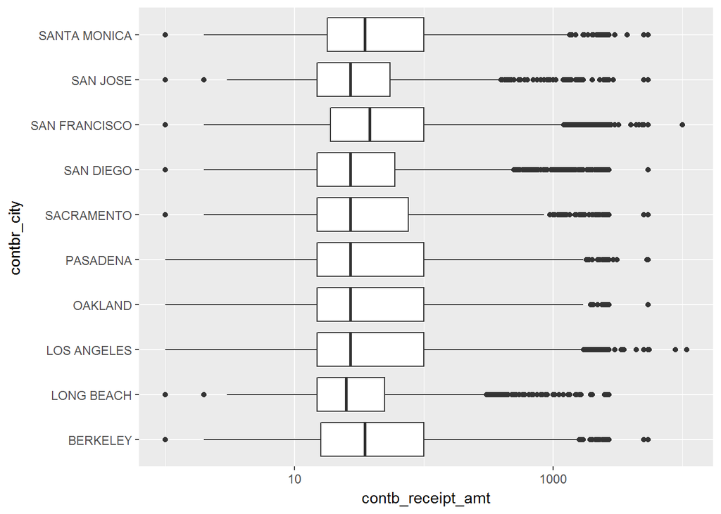

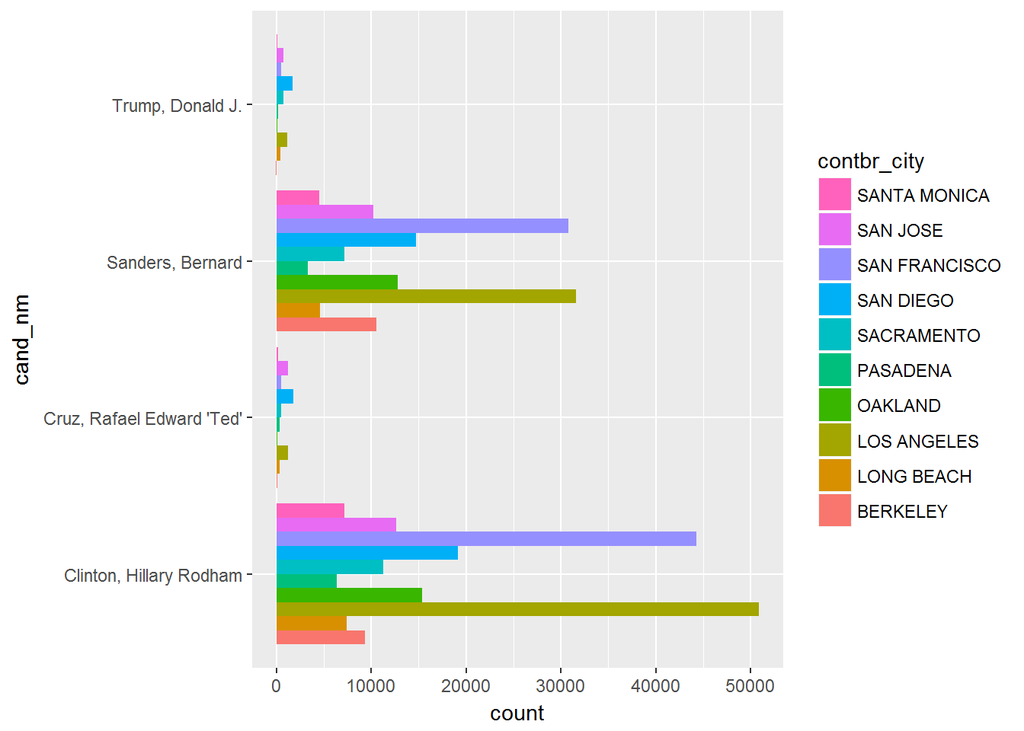

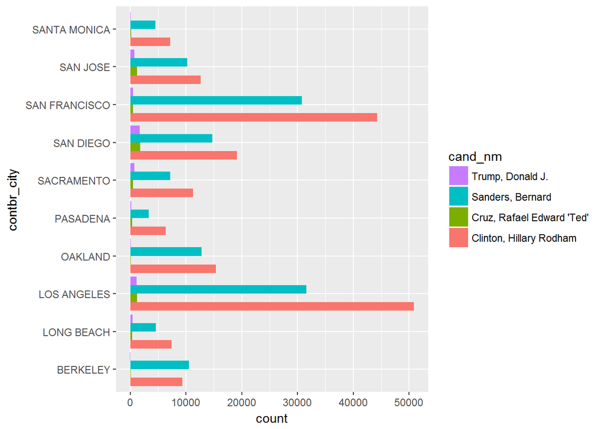

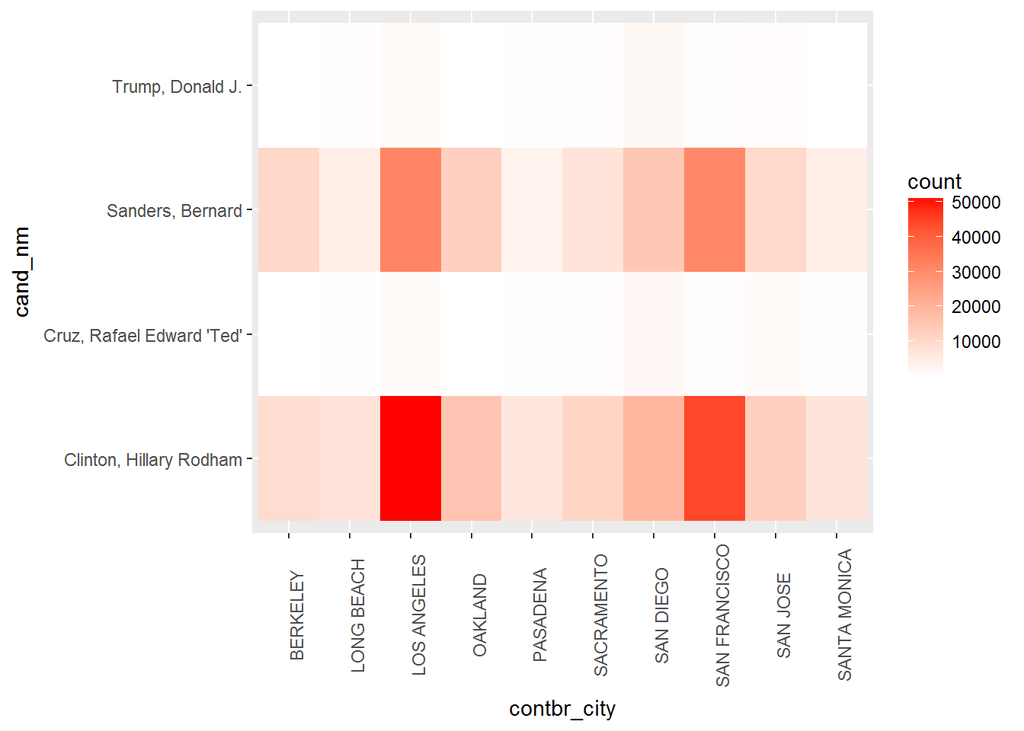

Concentrating on the most prominent four candidates, it’s interesting to see that some of the biggest cities, particularly Oakland and Berkeley, produced virtually no contributions to the republican candidates. But the whole of California appears to be overwhelmingly Democrat, with Hillary firmly in the lead.

Now to my tentative idea that the gender of contributors could be related to the gender of the recipients of their money.

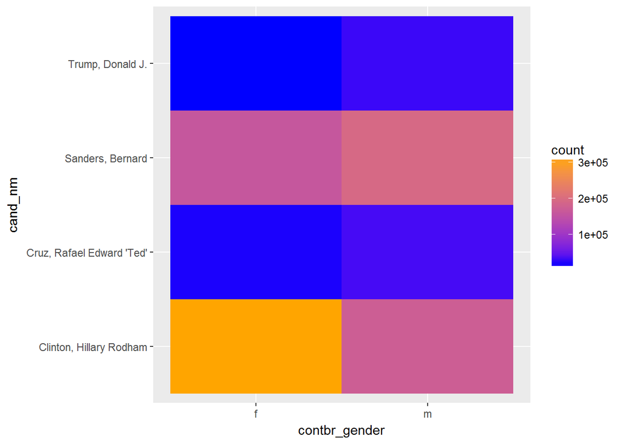

Indeed, it appears to be the case that most of the contributions from females went to Hillary, whereas males seemed to support male candidates more often.

# Bivariate Analysis

### Talk about some of the relationships you observed in this part of the investigation. How did the feature(s) of interest vary with other features in the dataset?

In this section I looked at how donation money amounts varied with occupation of the donor, and found an interesting relationship, namely that the most often donating retired and unemployed actually did not donate all that much.

I also looked at the top-10 cities by number of contributions in terms of who the contributions went to. The finding here is that California is unsurprisingly Democrat, but surprisingly some of the bigger cities showed virtually no support for the leading republican candidates. Quite a level of partisanship there.

### Did you observe any interesting relationships between the other features (not the main feature(s) of interest)?

While this was expected, another interesting thing that popped up was the difference between the median donation by occupation, and the median donation by occupation from unique individuals. A significant portion of contributors donated more than once, most prominently the “homemakers”, making them the group spending most money on average in their contributions.

### What was the strongest relationship you found?

Quite a strong relationship appeared between male and female contributions’ recipients. Between the four leading candidates, more than half of all female contributions were made to Hillary Clinton, but around 2/3 of male contributions went to Sanders, Cruz, and Trump. Male contributors gave to each male candidate significantly more often than female contributors did.

# Multivariate Plots Section

Let’s start this section by looking at the top-10 contributing cities and their contribution amounts to the four major candidates.

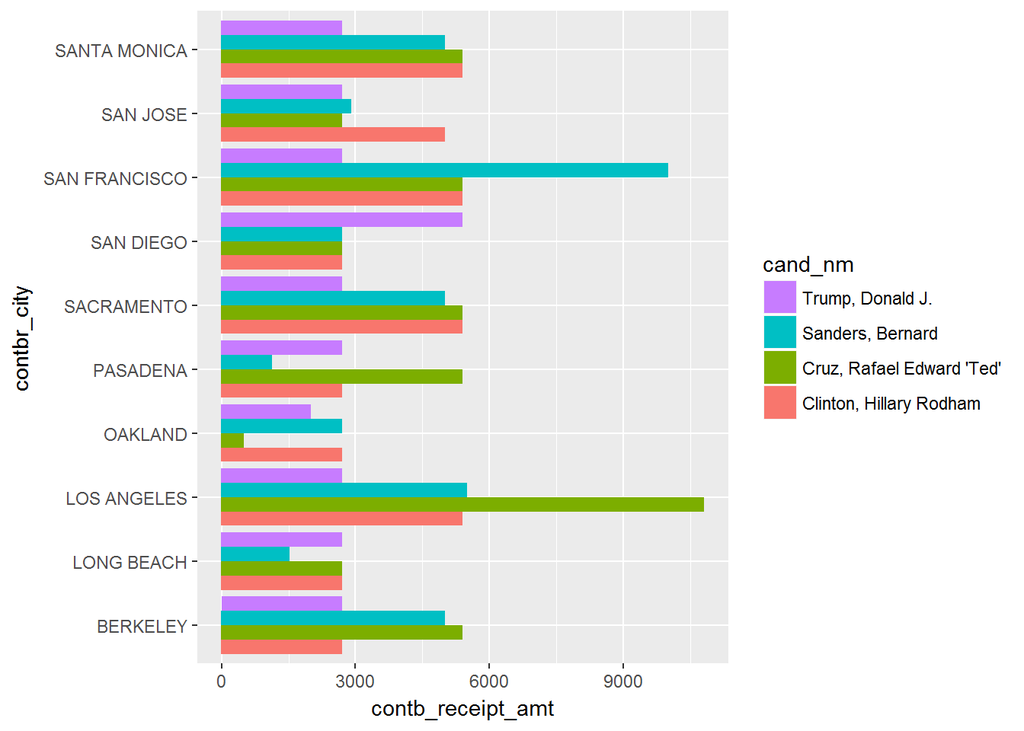

How did contribution amounts develop with time?

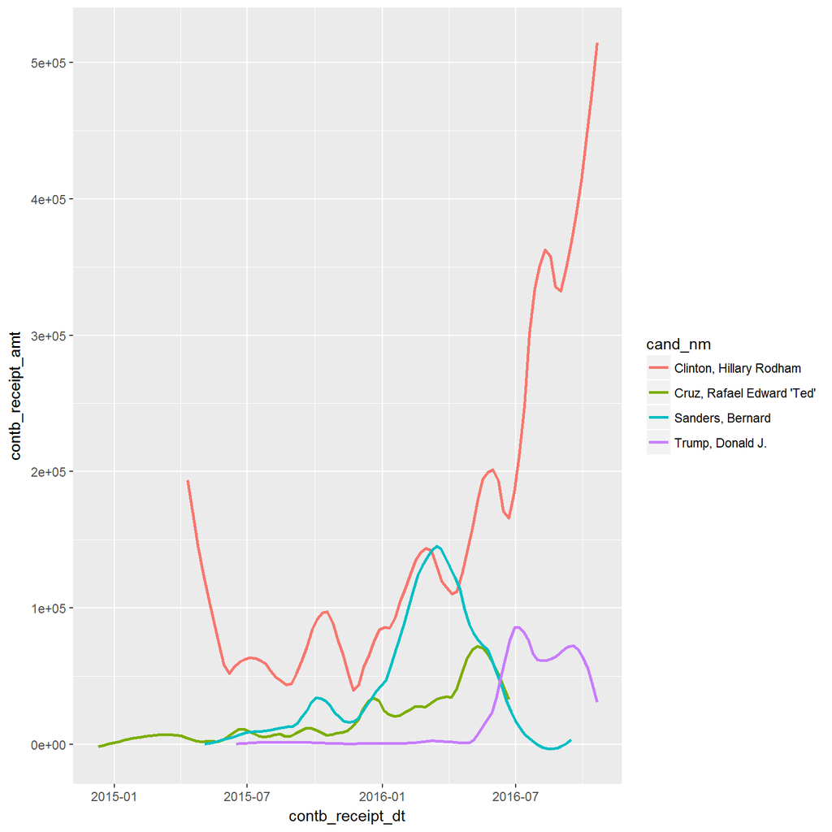

The most intriguing for me, however, would be to see how our top-10 occupations allocated their contributions. I’ll again look at amounts aggregated for each individual, and also differential between males and females.

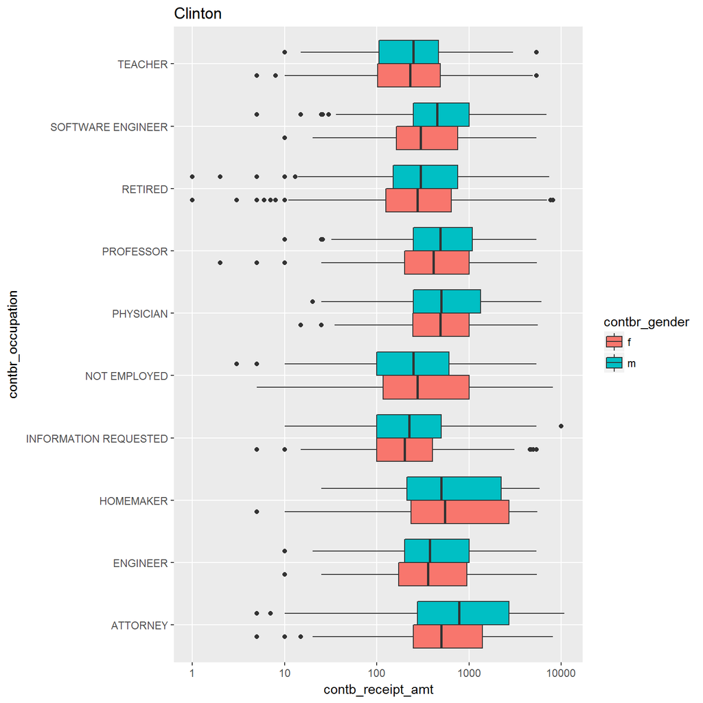

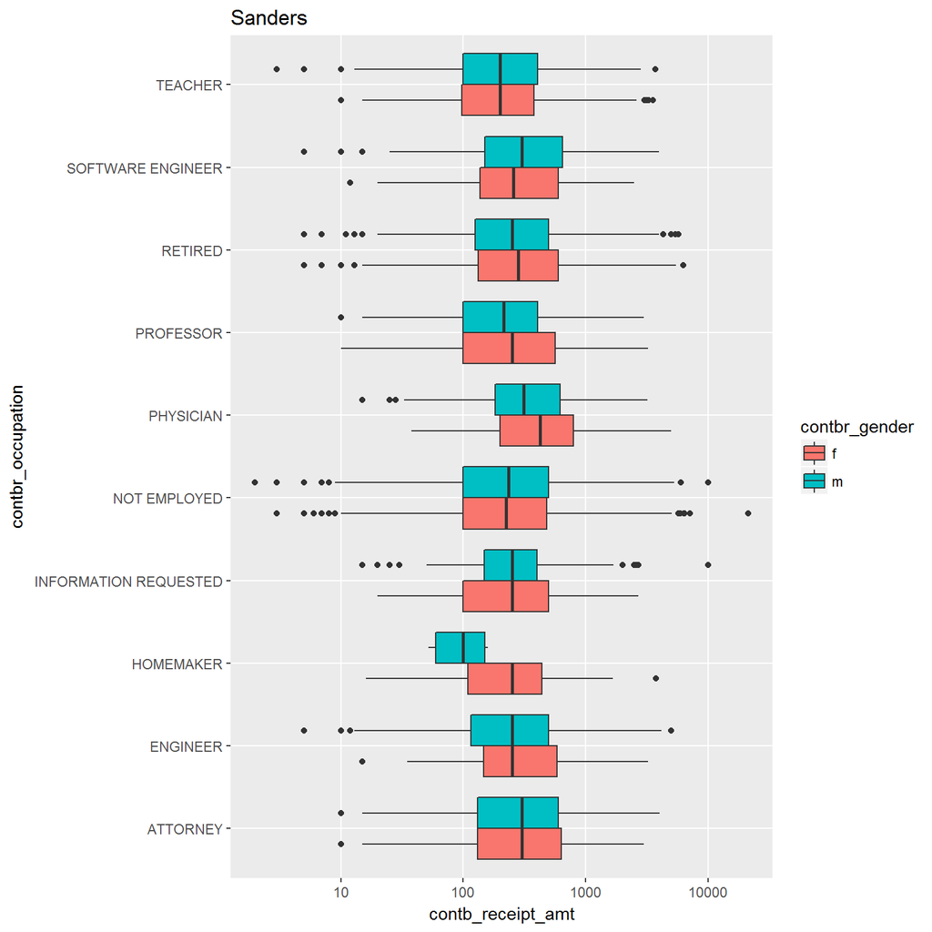

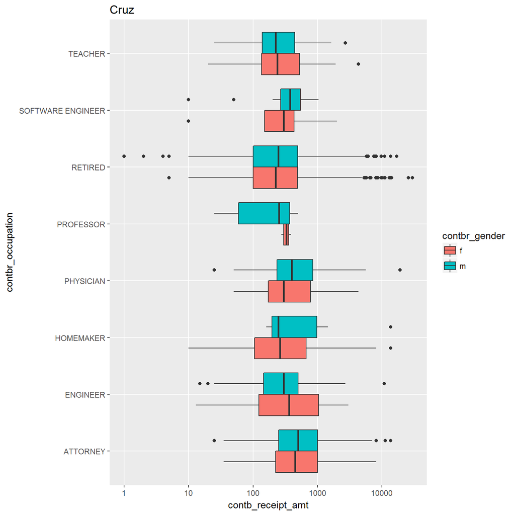

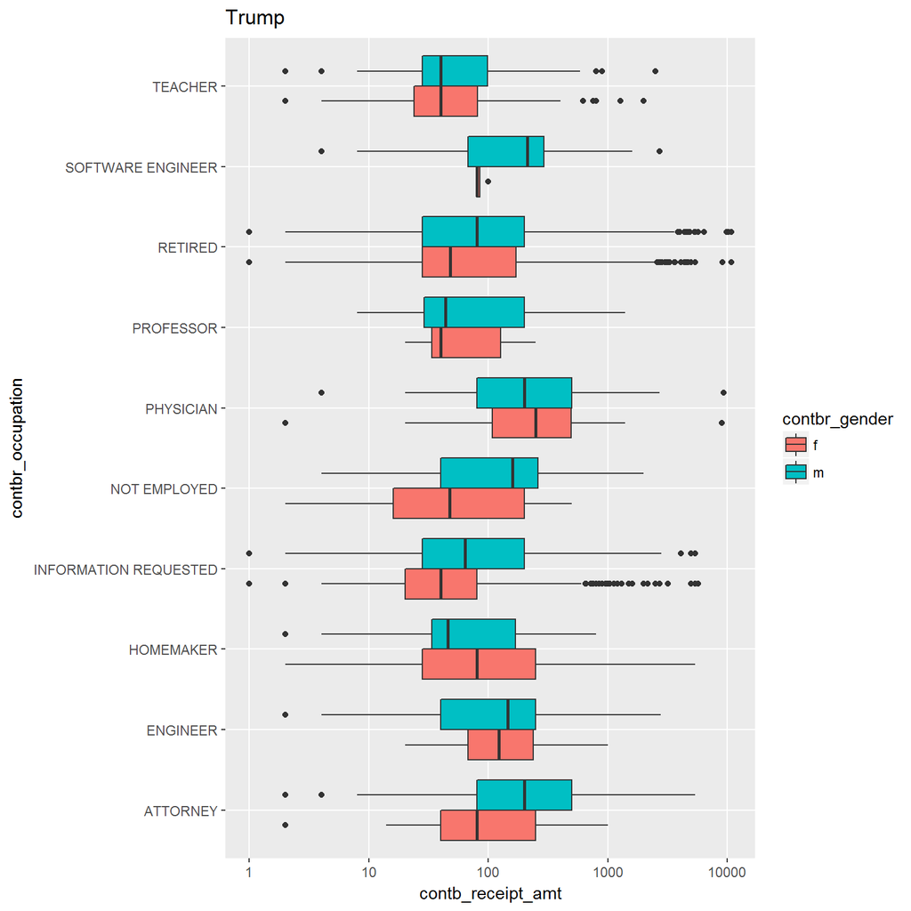

The separate graphs for each candidate highlight the differences. I’ll share some of my observations below. Note that the unemployed and the “information requested” categories made no contributions at all to Ted Cruz.

# Multivariate Analysis

### Talk about some of the relationships you observed in this part of the investigation. Were there features that strengthened each other in terms of looking at your feature(s) of interest?

The more interesting relationship between contributors’ occupations and their candidates does not appear to vary that strong with occupations, and somewhat varies by contributors’ gender.

### Were there any interesting or surprising interactions between features?

Some things that caught my eye:

### OPTIONAL: Did you create any models with your dataset? Discuss the strengths and limitations of your model.

I didn’t create any models with this dataset.

# Final Plots and Summary

### Plot One

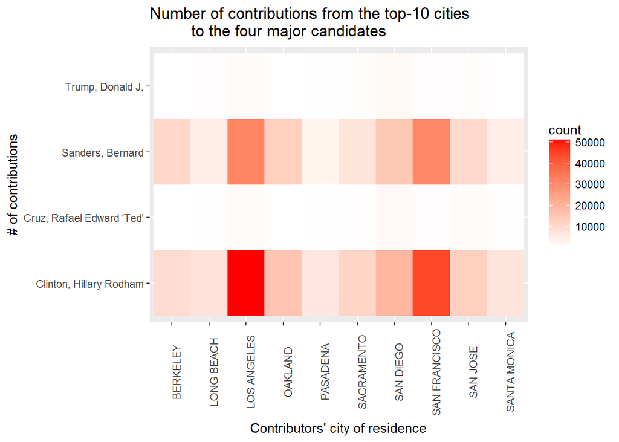

### Description One

In the first plot, we see roughly how many contributions from the top-10 cities went to each of the four major candidates. It makes for a pretty convincing picture of a total Democrat domination in California. Some cities showed zero or close to zero support for both Republicans, with even the highest level of support from San Diego and Los Angeles can barely be described as “lukewarm”.

### Plot Two

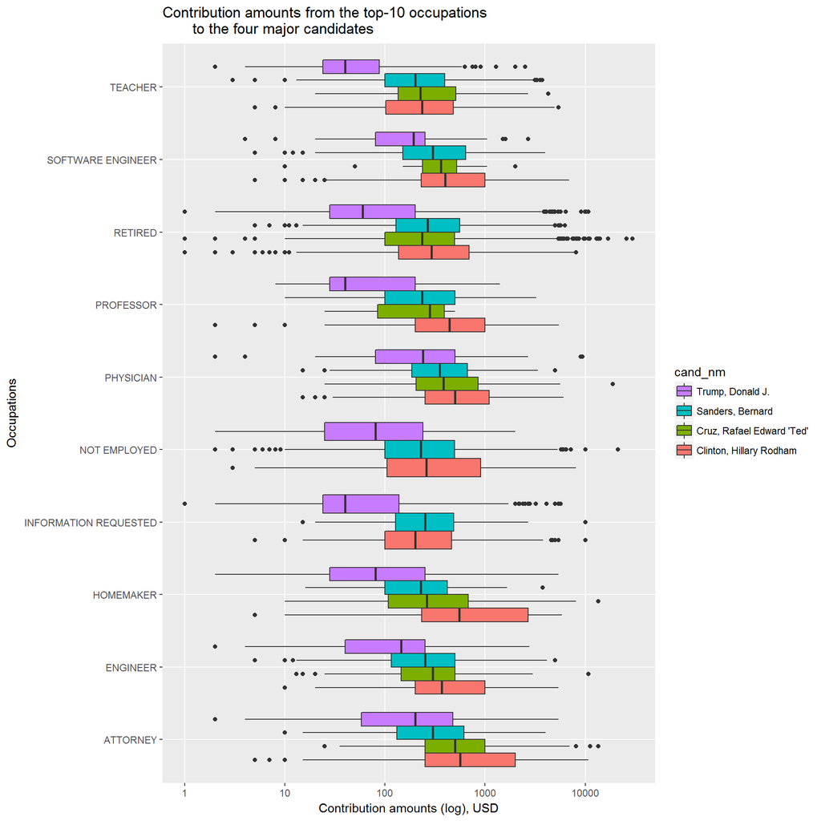

### Description Two

The second plot shows the dollar amounts of contributions to the four major candidates from the top-10 contribution occupations. Software Engineers, physicians and attorneys tend to give more on average. Clinton enjoyes the most relative support among homemakers, and the least among teachers and the retired. Interestingly, Ted Cruz appears to have gotten more money on average from these occupations than Sanders, a curious finding given that we’ve seen an enormous advantage for Sanders in contribution frequency. Another observation from this plot is that particularly the retired tend to show more variation in their donation amounts, and provide some of the highest outliers for the Repuiblican candidates. The “information requested” group also has very high variance for Trump support, but for some reason didn’t contribute to Cruz at all.

### Plot Three

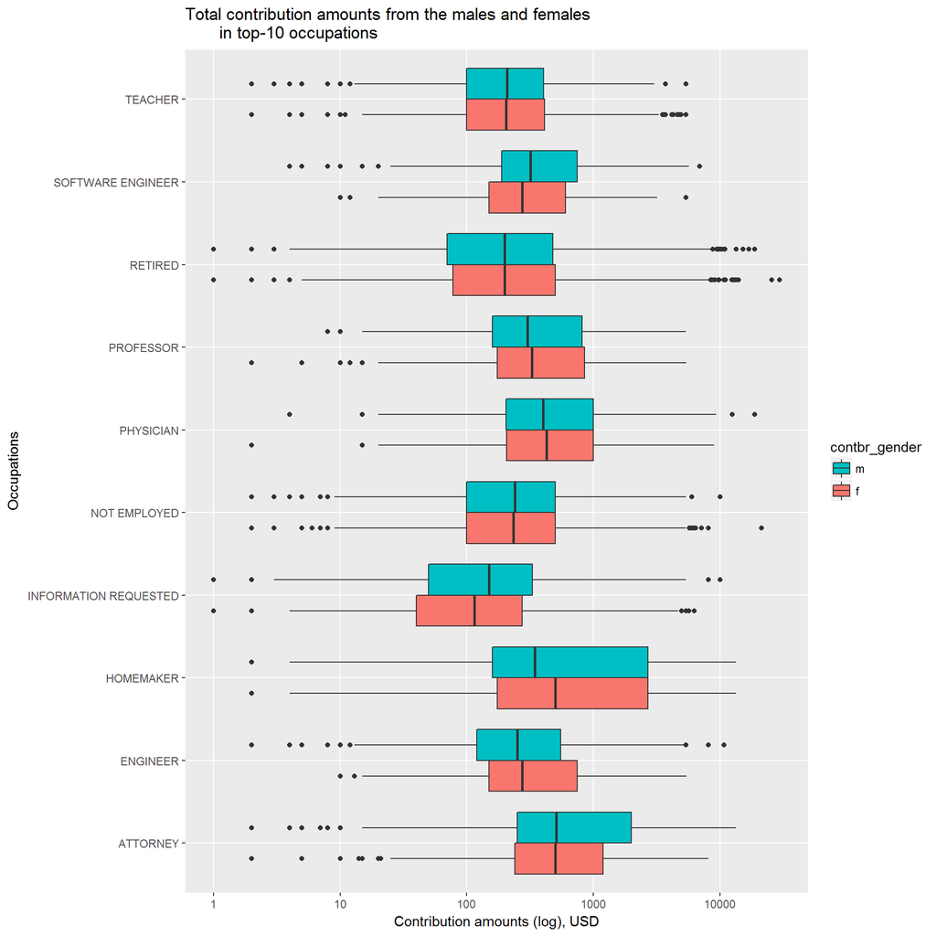

### Description Three

Finally, the third plot takes a closer look at gender differences in the top-10 occupations. Across most of them, men and women tend to contribute similar amounts. Males in undisclosed occupations (“information requested”) and software engineers tended to give more than women. At the same time, female homemakers and engineers appear to have contributed more than men. However, these observations should be taken with a grain of salt, considering my crude procedure for assigning contributor gender.

# Reflection

This dataset contains a well of exciting information, only a tiny part of which I could look at in this analysis. From over a million data points I could observe the tendency to donate round numbers (e.g. 10 or 100 dollars), a trend for the retired and the unemployed to contribute more often, but with smaller amounts, and a total domination of Democrat candidates over the Republican ones in California in terms of support. Across the state, women tended to support Hillary Clinton more often than men, and among the ten major cities only Los Angeles, San Diego, and San Jose showed visible, albeit meager, Republican support. There were some further trends between occupations and the gender of contributors that could be teased apart with more precise analysis.

I constructed a crude gender variable for the contributors based on their first names, and excluded data with negative or zero contribution amounts from the analysis. Further refinement could be achieved on these fronts. Furthermore, I only superficially looked at donation dates, and didn’t look at all at the contributors’ place of work.

Some difficulties I had with the analysis included reading the data at the beginning, and constructing the additional gender variable. I also hoped for more pronounced effects of occupation and gender on the donation amounts.

Further analysis could adress these topics in more detail, as well as attempt to construct a predictive model for candidate preference. For instance, one could try to fit a multinomial logistic regression to these data, using contribution amounts, contribution frequency, gender and occupation of contributors, and contribution date, to predict which candidate the given contribution went to. Alternatively, decision trees / random forests could be used for this purpose.